# Neuronal differentiation analysis

Melanie (1028-02098-001-001)

April 17, 2026

# Introduction

The goal of this analysis is to:

1. Map day0 motifs (ESCs) from day12 motifs (neural progenitors)
2. See whether there is a change from cooperative interactions of Sox2 with Oct4-Sox2 (loss of Oct4) to a different motif candidate that is specific to neural progenitors.

# Computational Setup

```r
#Standard packages
library(rtracklayer) ; library(GenomicRanges); library(magrittr) ; library(Biostrings)
library(ggplot2) ; library(reshape2); library(plyranges); library(Rsamtools); library(parallel)
library(dplyr); library(data.table); library(patchwork); library(readr); library(testit)

#KNITR Options
setwd("/n/projects/mw2098/publications/2024_weilert_acc/code/2_analysis/")
figure_filepath<-"figures/20_bunina_analysis"
options(knitr.figure_dir=figure_filepath, java.parameters = "- Xmx6g")

#Lab sources
source("scripts/r/granges_common.r")
source("scripts/r/metapeak_common.r")
source("scripts/r/knitr_common.r")
source("scripts/r/caching.r")
source("scripts/r/metapeak_functions.r")

#Specific sources
library(BSgenome.Mmusculus.UCSC.mm10)
library(TxDb.Mmusculus.UCSC.mm10.knownGene)
library(org.Mm.eg.db)
library(ggseqlogo)
library(DESeq2)
source("scripts/r/motif_functions.r")

#Pre-existing variables
threads <- 5
bsgenome<-BSgenome.Mmusculus.UCSC.mm10
txdb<-TxDb.Mmusculus.UCSC.mm10.knownGene

#model information
peaks.path<-'bed/bpreveal/bunina_atac_day0_across_combined_fold1_all.bed'
input_length<-2032
output_length<-1000

shap.bw.list<-list(`day0` = 'shap/bunina_atac_day0_across_combined_fold1_atac_counts.bw',
                   `day4` = 'shap/bunina_atac_day4_across_combined_fold1_atac_counts.bw',
                   `day8` = 'shap/bunina_atac_day8_across_combined_fold1_atac_counts.bw',
                   `day12` = 'shap/bunina_atac_day12_across_combined_fold1_atac_counts.bw')
```

# Curate motifs

From fold1 of day0 and day12, identify motifs that are commonly occuring.

```r
seqlet_ids.list<-list(
  fold1 = list(
    bunina_atac_day0 = data.frame(
      metacluster_name = 'pos_patterns', # Need this if you also have negative patterns
      pattern_name = c('pattern_0', 'pattern_1', 'pattern_2', 'pattern_3', 'pattern_4',
                       'pattern_5','pattern_6', 'pattern_7', 'pattern_8', 'pattern_9',
                       'pattern_10', 'pattern_11', 'pattern_12', 'pattern_13', 'pattern_14',
                       'pattern_15'),
      motif = c('Sp1', 'Nfy', 'Klf4', 'Oct4-Sox2', 'Ctcf',
                'Sox2','Nrf1', 'Creb', 'Oct4-Sox2','Nrf1',
                'Elk', 'Ctcf', 'Ctcf', 'Thap11', 'Tead',
                'Zbtb33'),
      oriented_strand = c('+', '-' , '+', '+', '-',
                          '+', '+', '+', '+', '+',
                          '-', '-', '-', '+', '+',
                          '+'),
      task = 'atac'),

    bunina_atac_day8 = data.frame(
      metacluster_name = 'pos_patterns', # Need this if you also have negative patterns
      pattern_name = c('pattern_0', 'pattern_1', 'pattern_2', 'pattern_3', 'pattern_4',
                       'pattern_5','pattern_6', 'pattern_7', 'pattern_8', 'pattern_9',
                       'pattern_10', 'pattern_11', 'pattern_12', 'pattern_13', 'pattern_14',
                       'pattern_15', 'pattern_16'),
      motif = c('Sp1', 'Nfy', 'Nrf1', 'Crcf', 'Sox2',
                'Elk','Creb', 'Thap11', 'Rfx', 'Pbx2/Meis',
                'Zbtb33', 'TGAGCTA', 'Elk-TGAGCTA', 'Elk-Elk', 'Rfx',
                'Rfx', 'Rfx'),
      oriented_strand = c('+', '+' , '+', '-', '+',
                          '-', '+', '+', '+', '+',
                          '+', '-', '-', '+', '+',
                          '+', '+'),
      task = 'atac'),

    bunina_atac_day12 = data.frame(
      metacluster_name = 'pos_patterns', # Need this if you also have negative patterns
      pattern_name = c('pattern_0', 'pattern_1', 'pattern_2', 'pattern_3', 'pattern_4',
                       'pattern_5','pattern_6', 'pattern_7', 'pattern_8', 'pattern_9',
                       'pattern_10', 'pattern_11', 'pattern_12'),
      motif = c('Sp1', 'Nfy', 'Nrf1', 'Creb', 'Elk',
                'Thap11', 'Rfx','Ctcf', 'Lhx', 'Cbx',
                'Sox-like','Ctcf', 'Ctcf'),
      oriented_strand = c('+', '-' , '+', '+', '-',
                          '+', '+', '+', '+', '+',
                          '+', '+', '+'),
      task = 'atac')
  )
)

seqlet_ids.df<-lapply(seqlet_ids.list, function(x){
  x %>% rbindlist(idcol = 'model')
}) %>% rbindlist(idcol = 'fold')
readr::write_tsv(seqlet_ids.df, 'tsv/mapped_motifs/bunina_pattern_ids.tsv')
```

## Import hits

Using fold1, import all hits from the key motifs of interest.

```r
hits.list<-lapply(names(seqlet_ids.list$fold1), function(model){
  df<-lapply(Sys.glob(paste0('modiscolite/', model, '*_fold1_*counts/hits.tsv')),
                     function(x) readr::read_tsv(x) %>%
                       dplyr::mutate(model = model,
                                     fold = 'fold1')) %>%
    rbindlist() %>% as.data.frame %>%
    dplyr::left_join(., seqlet_ids.df) %>%
    dplyr::filter(!is.na(motif))
  print(table(df$motif))
  return(df)
})
```

```
##
##      Creb      Ctcf       Elk      Klf4       Nfy      Nrf1 Oct4-Sox2      Sox2
##     12632     36070     10287    148131     27447     59878     14402     10049
##       Sp1      Tead    Thap11    Zbtb33
##     65959     68246      3286      3701
```

```
##
##        Crcf        Creb         Elk     Elk-Elk Elk-TGAGCTA         Nfy
##        6487       11693        8468        2471        1733       32461
##        Nrf1   Pbx2/Meis         Rfx        Sox2         Sp1     TGAGCTA
##       16261        4198        6792       10309       54790       10718
##      Thap11      Zbtb33
##        3425        2220
```

```
##
##      Cbx     Creb     Ctcf      Elk      Lhx      Nfy     Nrf1      Rfx
##    45580    19872    85665    12860    30839    27075    31557     4851
## Sox-like      Sp1   Thap11
##     5477    58703     4872
```

```r
names(hits.list)<-names(seqlet_ids.list$fold1)
```

## Curate motifs redundancy

Remove the following redundancies:

- Motifs that are peak-redundant will be mapped across peak “indexes” that are actually located across overlapping genomic regions.
- Motifs that are palindromic will be mapped on the positive and negative strand with almost identical ranges.
  - Here, we will remove redundantly mapped motifs and select the unique motif maps that have the highest contribution.
- Motifs that have sub-components such as Sox2 mapped over an Oct4-Sox2 motif. We will assign Oct4-Sox2 motifs as the prior.
- Motifs that have sub-components such as Nanog mapped over an Oct4-Sox2/Sox2 motif. We will assign Oct4-Sox2/Sox2 motifs as the prior.

In order to simultaneously manage peak-redundancy and palindromic motifs, we will have to assign generalized “peak islands” intead of `peak_index` as our grouped region sets.

```r
hits_dedup.list<-lapply(names(hits.list), function(model){
  #Orient strand to match desired aligned convention
  gr<-makeGRangesFromDataFrame(hits.list[[model]], keep.extra.columns = T, starts.in.df.are.0based = T) %>%
    plyranges::mutate(strand = ifelse(oriented_strand == '-',
                                      ifelse(strand == '-', '+', '-'),
                                      strand))

  #Import peaks and reduce them to a deduplicated state to get general peak regions.
  peaks.gr<-rtracklayer::import(peaks.path) %>%
    GenomicRanges::resize(., input_length, fix = 'center') %>%
    GenomicRanges::reduce(., ignore.strand = T) %>%
    plyranges::mutate(region_id_tmp = 1:length(.))

  #Find overlaps between motifs and peaks
  ov<-findOverlaps(gr, peaks.gr, ignore.strand = T)

  #Assign temporary region ID for deduplication
  gr$region_id_tmp<-NA
  gr$region_id_tmp[ov@from]<-peaks.gr$region_id_tmp[ov@to]

  #Filter any motif that doesn't fit into peaks. This means that the motif is mapped on the edges of the general, temporary region_id
  gr<-gr %>% plyranges::filter(!is.na(gr$region_id_tmp))

  #Deduplicate any motifs for palindromic mappings
  dedup.gr<-lapply(unique(gr$motif), function(y){
    print(y)
    motifs.gr<-gr %>% plyranges::filter(motif==y)
    motifs_dedup.gr<-remove_palindromic_motifs_from_bpnet_instances(dfi = motifs.gr,
                                                                    pattern_to_filter = y,
                                                                    chrom_name = 'seqnames', start_name = 'start', end_name = 'end',
                                                                    value_name = 'contrib_match', motif_name = 'motif',
                                                                    region_name = 'region_id_tmp')
    print(paste0(length(motifs_dedup.gr) , ' kept from ', length(motifs.gr)))
    return(motifs_dedup.gr)
  }) %>% as('GRangesList') %>% unlist(.)

  final_motifs.gr<-dedup.gr %>%
    plyranges::select(-c(oriented_strand, fold))

  return(final_motifs.gr)
})
```

```
## [1] "Sp1"
```

```
## [1] "23940 kept from 65959"
## [1] "Ctcf"
```

```
## [1] "11710 kept from 36070"
## [1] "Tead"
```

```
## [1] "22515 kept from 68246"
## [1] "Elk"
```

```
## [1] "3752 kept from 10287"
## [1] "Nfy"
```

```
## [1] "9866 kept from 27447"
## [1] "Klf4"
```

```
## [1] "52569 kept from 148131"
## [1] "Nrf1"
```

```
## [1] "12136 kept from 59878"
## [1] "Oct4-Sox2"
```

```
## [1] "7864 kept from 14402"
## [1] "Zbtb33"
```

```
## [1] "2641 kept from 3701"
## [1] "Sox2"
```

```
## [1] "7100 kept from 10049"
## [1] "Creb"
```

```
## [1] "2451 kept from 12632"
## [1] "Thap11"
```

```
## [1] "995 kept from 3286"
## [1] "Sp1"
```

```
## [1] "18784 kept from 54788"
## [1] "Nfy"
```

```
## [1] "12109 kept from 32456"
## [1] "TGAGCTA"
```

```
## [1] "3385 kept from 10718"
## [1] "Elk-TGAGCTA"
```

```
## [1] "673 kept from 1733"
## [1] "Elk-Elk"
```

```
## [1] "1002 kept from 2471"
## [1] "Nrf1"
```

```
## [1] "3274 kept from 16261"
## [1] "Sox2"
```

```
## [1] "6719 kept from 10305"
## [1] "Elk"
```

```
## [1] "2942 kept from 8468"
## [1] "Pbx2/Meis"
```

```
## [1] "2715 kept from 4188"
## [1] "Crcf"
```

```
## [1] "3327 kept from 6487"
## [1] "Thap11"
```

```
## [1] "1006 kept from 3425"
## [1] "Zbtb33"
```

```
## [1] "374 kept from 2220"
## [1] "Rfx"
```

```
## [1] "1940 kept from 6784"
## [1] "Creb"
```

```
## [1] "2189 kept from 11693"
## [1] "Sp1"
```

```
## [1] "19677 kept from 58701"
## [1] "Ctcf"
```

```
## [1] "22125 kept from 85663"
## [1] "Nfy"
```

```
## [1] "9603 kept from 27072"
## [1] "Creb"
```

```
## [1] "5783 kept from 19869"
## [1] "Elk"
```

```
## [1] "4332 kept from 12859"
## [1] "Nrf1"
```

```
## [1] "5211 kept from 31557"
## [1] "Lhx"
```

```
## [1] "12748 kept from 30822"
## [1] "Cbx"
```

```
## [1] "17764 kept from 45561"
## [1] "Sox-like"
```

```
## [1] "1883 kept from 5475"
## [1] "Thap11"
```

```
## [1] "1518 kept from 4872"
## [1] "Rfx"
```

```
## [1] "1418 kept from 4844"
```

```r
names(hits_dedup.list)<-names(hits.list)
```

## Double check motif overlaps

Ensure that there isn’t an overrepresentation of unexpected overlapping motif pairs. We expect some overlaps, but checking to make sure that our curations are consistent.

```r
lapply(hits_dedup.list, function(gr){
  reduced_motifs.gr<-gr %>% GenomicRanges::reduce(., ignore.strand = T, min.gapwidth = 0)
  gr$motif_id_tmp<-findOverlaps(gr, reduced_motifs.gr, ignore.strand = T)@to
  motifs_overlapped_ids<-table(gr$motif_id_tmp)[table(gr$motif_id_tmp)>1]

  gr %>%
    as.data.frame %>%
    dplyr::filter(motif_id_tmp %in% names(motifs_overlapped_ids)) %>%
    dplyr::group_by(motif_id_tmp) %>%
    dplyr::summarize(overlapping_motif_name = paste0(sort(motif), collapse = ':')) %>%
    .$overlapping_motif_name %>%
    table(.) %>%
    sort(decreasing = T) %>%
    head(n=30)
})
```

```
## $bunina_atac_day0
## .
##                Klf4:Sp1          Ctcf:Klf4:Tead               Klf4:Tead
##                   18357                    5031                    3790
##               Ctcf:Tead           Klf4:Sp1:Tead          Oct4-Sox2:Sox2
##                    3131                    2328                    1882
##               Klf4:Nrf1           Klf4:Nrf1:Sp1     Ctcf:Klf4:Nrf1:Tead
##                    1369                    1279                    1211
##                Elk:Tead          Klf4:Nrf1:Tead      Klf4:Nrf1:Sp1:Tead
##                     336                     324                     321
##      Ctcf:Klf4:Sp1:Tead               Nrf1:Tead                Nfy:Sox2
##                     313                     226                     222
##                Elk:Nrf1               Ctcf:Klf4          Ctcf:Nrf1:Tead
##                     209                     179                     152
##  Klf4:Klf4:Sp1:Sp1:Tead                Klf4:Nfy             Tead:Zbtb33
##                     135                     134                     132
##               Klf4:Sox2                Elk:Klf4        Oct4-Sox2:Zbtb33
##                     127                     123                     118
##           Ctcf:Elk:Tead          Ctcf:Klf4:Nrf1          Klf4:Klf4:Tead
##                     104                     103                      93
##     Ctcf:Klf4:Klf4:Tead Ctcf:Klf4:Nrf1:Sp1:Tead      Klf4:Klf4:Sp1:Tead
##                      91                      86                      85
##
## $bunina_atac_day8
## .
##                 Creb:TGAGCTA                     Nfy:Sox2
##                         1311                          750
##                  Elk:Elk-Elk     Creb:Elk-TGAGCTA:TGAGCTA
##                          508                          331
##          Elk-TGAGCTA:TGAGCTA              Elk:Elk-TGAGCTA
##                          102                           67
##                  Elk-Elk:Sp1                      Elk:Sp1
##                           50                           42
##                Nfy:Pbx2/Meis                      Nfy:Sp1
##                           39                           37
##      Elk:Elk-TGAGCTA:TGAGCTA                     Crcf:Sp1
##                           36                           34
##              Elk:Elk-Elk:Sp1                 Crcf:Elk-Elk
##                           29                           27
## Creb:Elk:Elk-TGAGCTA:TGAGCTA                     Nrf1:Sp1
```

[output cut: 23 more lines]

```
##                  290                  213                  213
##     Cbx:Lhx:Sox-like        Creb:Ctcf:Sp1     Cbx:Ctcf:Lhx:Nfy
##                  204                  199                  196
##             Cbx:Creb Cbx:Ctcf:Lhx:Nfy:Sp1             Creb:Elk
##                  185                  172                  160
##        Ctcf:Nrf1:Sp1            Creb:Ctcf             Cbx:Ctcf
##                  122                  101                  100
##         Cbx:Ctcf:Sp1         Cbx:Ctcf:Nfy         Cbx:Sox-like
##                   69                   58                   56
##           Cbx:Thap11     Cbx:Ctcf:Nfy:Sp1         Cbx:Creb:Lhx
##                   50                   46                   44
##         Cbx:Ctcf:Lhx           Elk:Thap11     Cbx:Ctcf:Lhx:Sp1
##                   41                   34                   33
##             Creb:Rfx         Lhx:Sox-like         Elk:Sox-like
##                   33                   32                   30
```

## Remove redundant motif instances

```r
hits_no_redundant.list<-lapply(names(hits_dedup.list), function(model){
  gr<-hits_dedup.list[[model]]
  no_redundant.gr<-remove_redundant_motifs_from_bpnet_instances(gr,chrom_name = 'seqnames', start_name = 'start', end_name = 'end',
                                                                value_name = 'contrib_magnitude',
                                                                region_name = 'region_id_tmp')

  return(no_redundant.gr)
})
names(hits_no_redundant.list)<-names(hits.list)
```

Compare changed numbers in motifs

```r
lapply(hits_dedup.list, function(x) x$motif %>% table)
```

```
## $bunina_atac_day0
## .
##      Creb      Ctcf       Elk      Klf4       Nfy      Nrf1 Oct4-Sox2      Sox2
##      2451     11710      3752     52569      9866     12136      7864      7100
##       Sp1      Tead    Thap11    Zbtb33
##     23940     22515       995      2641
##
## $bunina_atac_day8
## .
##        Crcf        Creb         Elk     Elk-Elk Elk-TGAGCTA         Nfy
##        3327        2189        2942        1002         673       12109
##        Nrf1   Pbx2/Meis         Rfx        Sox2         Sp1     TGAGCTA
##        3274        2715        1940        6719       18784        3385
##      Thap11      Zbtb33
##        1006         374
##
## $bunina_atac_day12
## .
##      Cbx     Creb     Ctcf      Elk      Lhx      Nfy     Nrf1      Rfx
##    17764     5783    22125     4332    12748     9603     5211     1418
## Sox-like      Sp1   Thap11
##     1883    19677     1518
```

```r
lapply(hits_no_redundant.list, function(x) x$motif %>% table)
```

```
## $bunina_atac_day0
## .
##      Creb      Ctcf       Elk      Klf4       Nfy      Nrf1 Oct4-Sox2      Sox2
##      2289      8348      2425     34775      9526      7819      7740      4523
##       Sp1      Tead    Thap11    Zbtb33
##      2859     11404       994      2099
##
## $bunina_atac_day8
## .
##        Crcf        Creb         Elk     Elk-Elk Elk-TGAGCTA         Nfy
##        3314        1803        2204         919         557       11854
##        Nrf1   Pbx2/Meis         Rfx        Sox2         Sp1     TGAGCTA
##        3253        2689        1930        6076       18602        1471
##      Thap11      Zbtb33
##        1004         366
##
## $bunina_atac_day12
## .
##      Cbx     Creb     Ctcf      Elk      Lhx      Nfy     Nrf1      Rfx
##     6388     5042    18959     3479    10461      498     4952     1413
## Sox-like      Sp1   Thap11
##     1662     4975     1505
```

We see a loss in the motifs we would expect to had they been redundant.

## Calculate islands

Because we took motifs based on their relative contribution and not the featured `peak_index` column, we need a new grouping annotation to define the motifs when we are conducting perturbations and other grouping systems. We will call this index `region_id`.

```r
motifs_w_annotations.gr.list<-lapply(names(hits_no_redundant.list), function(model){
  message(model)

  gr<-hits_no_redundant.list[[model]]

  islands.gr<-resize(gr, 150, 'center') %>%
    GenomicRanges::reduce(ignore.strand = T)
  # rtracklayer::export(islands.gr, 'bed/mapped_motifs/islands_raw.bed')

  data.frame(x = width(islands.gr)) %>%
    ggplot(., aes(x = x))+
    geom_density()

  #Filter islands that are >1000 bp
  islands.gr <- islands.gr %>% plyranges::filter(width <= input_length)  %>%
    plyranges::mutate(region_id = 0:(length(.)-1)) #Make region_id 0-based in order to be compatible with BPNet contribution .h5 file indexing properties.
  ov<-findOverlaps(gr, islands.gr, ignore.strand = T)
  islands_resized_to_output.gr <- islands.gr %>% GenomicRanges::resize(., width = output_length, fix = 'center')

  #Nice! No regions get filtered out this time. This is great.

  #Export regions in 0-based coordinates
  rtracklayer::export(islands.gr %>%
                        plyranges::mutate(name = region_id),
                      paste0('bed/mapped_motifs/all_', model, '_islands_curated_0based.bed'), format = 'BED')
  rtracklayer::export(islands.gr %>%
                        GenomicRanges::resize(., width = output_length, fix = 'center') %>%
                        plyranges::mutate(name = region_id),
                      paste0('bed/mapped_motifs/all_', model, '_islands_curated_0based_sized_to_output.bed'), format = 'BED')
  rtracklayer::export(islands.gr %>%
                        GenomicRanges::resize(., width = input_length, fix = 'center') %>%
                        plyranges::mutate(name = region_id),
                      paste0('bed/mapped_motifs/all_', model, '_islands_curated_0based_sized_to_input.bed'), format = 'BED')

  #Assign region_id to these motifs
  gr_w_regions.gr<-gr
  gr_w_regions.gr$region_id<-NA
  gr_w_regions.gr$region_id[ov@from]<-islands_resized_to_output.gr$region_id[ov@to]
  gr_w_regions.gr$region_start_1based<-NA
  gr_w_regions.gr$region_start_1based[ov@from]<-start(islands_resized_to_output.gr)[ov@to]
  gr_w_regions.gr$region_end_1based<-NA
  gr_w_regions.gr$region_end_1based[ov@from]<-end(islands_resized_to_output.gr)[ov@to]

  #Filter motifs that aren't in a sufficiently small island.
  gr_w_ic.gr <- gr_w_regions.gr %>% plyranges::filter(!is.na(region_id)) %>%
    plyranges::mutate(motif_id = 0:(length(.)-1), #0-based indexing later might come in handy
                      seq = getSeq(bsgenome, ., as.character = T))

  #1-based
  gr_w_ic.df<-gr_w_ic.gr %>% as.data.frame()
  readr::write_tsv(gr_w_ic.df, paste0('tsv/mapped_motifs/all_', model, '_instances_curated_1based.tsv.gz'))

  #0-based
  rtracklayer::export(gr_w_ic.gr %>% plyranges::mutate(name = paste0(motif, '_', motif_id, '_', region_id)),
                      paste0('bed/mapped_motifs/all_', model, '_instances_curated_0based.bed'))
  return(gr_w_ic.gr)

})
names(motifs_w_annotations.gr.list)<-names(hits.list)
```

# Plot SHAP scores of different concentrations across mapped motifs

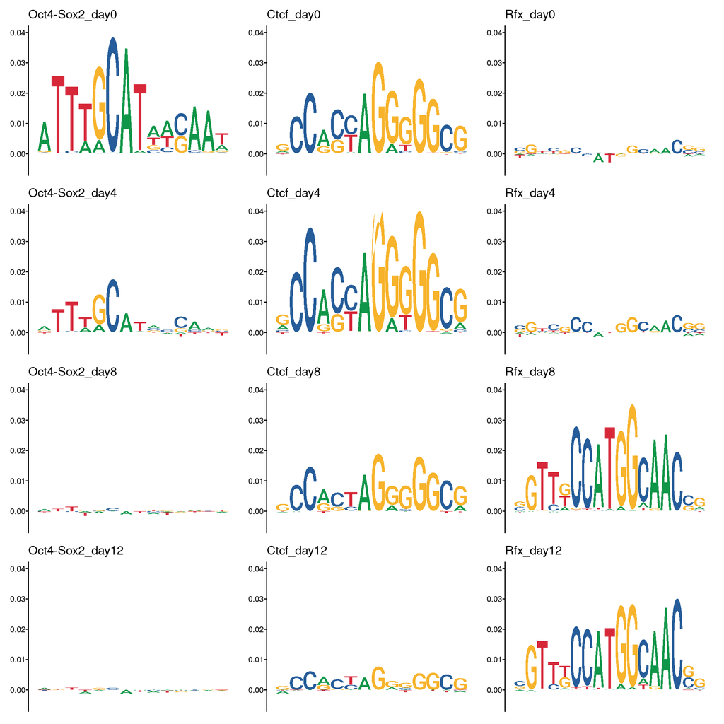

```r
motifs_of_interest.gr<-c(
  motifs_w_annotations.gr.list$bunina_atac_day0 %>% plyranges::filter(motif=='Oct4-Sox2', pattern_name== 'pattern_3'),
  motifs_w_annotations.gr.list$bunina_atac_day0 %>% plyranges::filter(motif=='Ctcf', pattern_name== 'pattern_4'),
  motifs_w_annotations.gr.list$bunina_atac_day12 %>% plyranges::filter(motif=='Rfx')
)


cwms.plot.list<-lapply(motifs_of_interest.gr$motif %>% unique, function(x){
  message(x)
  logos.plot.list<-mclapply(names(shap.bw.list), function(y){
    message(y)
      gr<-motifs_of_interest.gr %>% plyranges::filter(motif==x)
      seqs<-gr %>% getSeq(bsgenome, ., as.character = T)
      contrib.mat<-standard_metapeak_matrix(regions.gr = gr,
                                            sample.cov = shap.bw.list[[y]],
                                            keep_region_coordinates = T)
      seqs_1he.list<-lapply(seqs, function(z) one_hot_encode_DNA(z))
      contribs.list<-lapply(1:dim(contrib.mat)[1], function(z){
        seqs_1he.list[[z]] * matrix(rep(contrib.mat[z,], 4), nrow = 4, byrow = T)
      })
      cwm<-Reduce("+", contribs.list) / length(contribs.list)

      cwm.plot<-ggseqlogo(cwm, method = 'custom', seq_type='dna')+
        scale_x_continuous(name = 'Motif position (bp)')+
        scale_y_continuous(name = 'Contrib', limits = c(-.005, .04))+
        ggtitle(paste0(x, '_', y)) +
        theme(axis.line.y = element_line(), axis.ticks.y = element_line(),
              axis.title = element_blank(), axis.text.x = element_blank())
    return(cwm.plot)
  }, mc.cores = 2)

  logos.plot<-wrap_plots(logos.plot.list) + plot_layout(ncol = 1)
  ggsave(paste0(figure_filepath, '/cwm_across_mapped_', x, '.png'), logos.plot, height = 9, width = 3)
  ggsave(paste0(figure_filepath, '/cwm_across_mapped_', x, '.pdf'), logos.plot, height = 9, width = 3)

  return(logos.plot)
})

all_logos.plot<-wrap_plots(cwms.plot.list) + plot_layout(nrow = 1)
all_logos.plot
```

```r
ggsave(paste0(figure_filepath, '/cwm_across_mapped_all.png'), all_logos.plot, height = 11, width = 12)
ggsave(paste0(figure_filepath, '/cwm_across_mapped_all.pdf'), all_logos.plot, height = 11, width = 12)
```

# Find candidates of Sox2 cooperativity

```r
#Find regions that have Rfx and Oct4-Sox2 nearby
subsetByOverlaps(motifs_w_annotations.gr.list$bunina_atac_day0 %>% plyranges::filter(motif %in% c('Oct4-Sox2')),
                 motifs_w_annotations.gr.list$bunina_atac_day8 %>% plyranges::filter(motif=='Sox2')) %>%
  GenomicRanges::resize(., 400, 'center') %>%
  subsetByOverlaps(.,
                   motifs_w_annotations.gr.list$bunina_atac_day8 %>% plyranges::filter(motif=='Pbx2/Meis')) %>%
  plyranges::arrange(desc(contrib_magnitude)) %>% as.data.frame
```

```
##    seqnames     start       end width strand short_name contrib_magnitude
## 1      chr8  67086311  67086710   400      -      pos_8         0.9343643
## 2     chr13  84059602  84060001   400      -      pos_8         0.7302628
## 3     chr17  34325291  34325690   400      +      pos_8         0.6410065
## 4      chr1 165966553 165966952   400      -      pos_8         0.6115150
## 5     chr18  63924615  63925014   400      +      pos_8         0.5862923
## 6     chr13  42412635  42413034   400      -      pos_8         0.5306778
## 7      chr7 113048374 113048773   400      -      pos_8         0.3982668
## 8     chr12  89530900  89531299   400      -      pos_8         0.3749924
## 9     chr11  25753507  25753906   400      +      pos_3         0.3472304
## 10     chr2 117938803 117939202   400      +      pos_8         0.3122573
## 11     chr2 106822504 106822903   400      -      pos_8         0.2942772
## 12    chr10  99538659  99539058   400      -      pos_8         0.2790222
## 13    chr14  98155029  98155428   400      +      pos_8         0.2582207
## 14     chr1  18831005  18831404   400      +      pos_8         0.2410524
```

[output cut: 49 more lines]

```r
#chr11:71,996,116-71,996,273 #immediate cooperativity thats super nice bw sox2 and rfx
#chr13:84,059,688-84,059,837 great candidate showing perfect cooperativity handover
#chr2:117,938,915-117,939,042 secondary candidate
#chr10:99,538,846-99,538,942 good secondary candidate
```

# GM17750 intronic enhancer showcase

## Showcase the contribution tracks

```r
curated_enhancer_boundaries.gr<- GRanges('chr13', IRanges(84059730,84059820))
```

Generate contribution scores of mapped motifs.

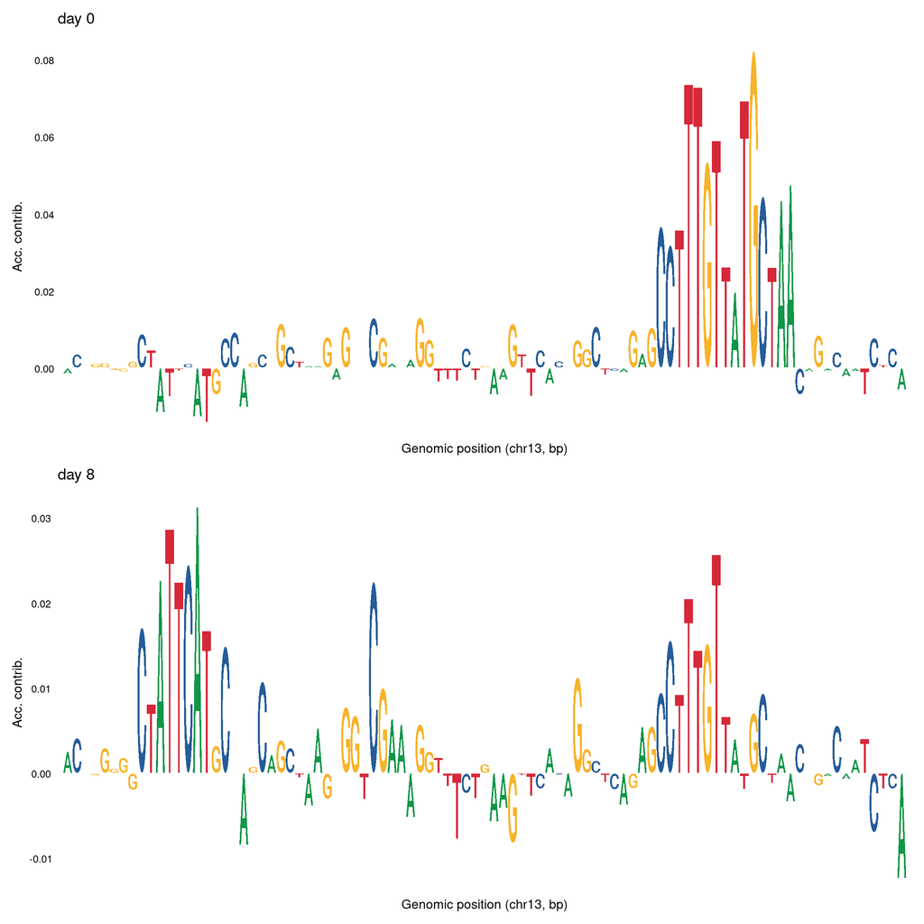

```r
acc_contrib.plot<-lapply(c(0, 8), function(x){

  curated_enhancer.df<-data.frame(
    acc_contrib = standard_metapeak_matrix(regions.gr =curated_enhancer_boundaries.gr, sample.cov = paste0('shap/bunina_atac_day', x, '_across_combined_fold1_atac_counts.bw'),
                                           keep_region_coordinates = T) %>% t(),
    seq = getSeq(bsgenome, curated_enhancer_boundaries.gr, as.character = T) %>% stringr::str_split_1(pattern = ''),
    position = start(curated_enhancer_boundaries.gr):end(curated_enhancer_boundaries.gr)
  )

  # Generate sequence logo
  acc_contrib.plot<-curated_enhancer.df%>%
    tidyr::pivot_wider(names_from = seq, values_from = acc_contrib) %>%
    dplyr::select(A, C, G, T) %>% as.matrix() %>% t() %>%
    ggseqlogo(., method='custom', seq_type='dna') +
    scale_y_continuous(name = 'Acc. contrib.')+
    scale_x_discrete(name = 'Genomic position (chr13, bp)')+
    ggtitle(paste0('day ', x))
}) %>% wrap_plots(ncol = 1)

acc_contrib.plot
```

```r
ggsave(paste0(figure_filepath, '/GM17750_contrib.png'), acc_contrib.plot, height = 3, width = 10)
ggsave(paste0(figure_filepath, '/GM17750_contrib.pdf'), acc_contrib.plot, height = 3, width = 10)
```

## Showcase cooperativity between timepoints

Arrange motifs

```r
candidate_island.df<-curated_enhancer_boundaries.gr %>% plyranges::mutate(region_id = 0, comb_max = 2, comb_min = 1) %>% GenomicRanges::resize(., width = 2033, 'center') %>% as.data.frame()%>%
  dplyr::rename(chrom = seqnames)
candidate_motifs.df<-c(subsetByOverlaps(motifs_w_annotations.gr.list$bunina_atac_day0, curated_enhancer_boundaries.gr, ignore.strand = T),
  subsetByOverlaps(motifs_w_annotations.gr.list$bunina_atac_day8, curated_enhancer_boundaries.gr, ignore.strand = T)) %>%
  as.data.frame() %>%
  plyranges::mutate(region_id = 0,
                    start = start,
                    end = end+1,
                    motif_window_start = start - candidate_island.df$start,
                    motif_window_end = end - candidate_island.df$start)  %>%
  dplyr::rename(chrom = seqnames) #all motifs are on negative strand
readr::write_tsv(candidate_motifs.df,
                 'tsv/genomic/motifs/bunina_showcase_instances_formatted_for_genomic_perturbations_0based.tsv.gz')
readr::write_tsv(candidate_island.df,
                 'tsv/genomic/motifs/bunina_showcase_islands_formatted_for_genomic_perturbations_0based.tsv.gz')
```

Calculate cooperativity

```bash
source /home/mw2098/.bashrc
conda deactivate
conda activate bpreveal_404
cd /n/projects/mw2098/publications/2024_weilert_acc/code/2_analysis

/home/mw2098/anaconda3/envs/bpreveal_404/bin/python scripts/py/tools/generate_genomic_perturbs.py \
--motifs_df_path tsv/genomic/motifs/bunina_showcase_instances_formatted_for_genomic_perturbations_0based.tsv.gz \
--motif_groups_df_path tsv/genomic/motifs/bunina_showcase_islands_formatted_for_genomic_perturbations_0based.tsv.gz \
--model_dir models/bunina_atac_day0_across_combined_fold1_combined.model / \
--output_prefix tsv/genomic/motifs/bunina_showcase_instances_day0 \
--tasks_in_model_order atac \
--region_index_column region_id \
--motif_window_start_column motif_window_start \
--motif_window_end_column motif_window_end \
--motif_name_column motif \
--motif_chrom_column chrom \
--fasta_file ../0_setup/fa/mm10.fa \
--input_seqlen 2032 --output_seqlen 1000 \
--comb_max comb_max --comb_min comb_min \
--nodes 1 --trials 16 \
--use_whole_window

/home/mw2098/anaconda3/envs/bpreveal_404/bin/python scripts/py/tools/generate_genomic_perturbs.py \
--motifs_df_path tsv/genomic/motifs/bunina_showcase_instances_formatted_for_genomic_perturbations_0based.tsv.gz \
--motif_groups_df_path tsv/genomic/motifs/bunina_showcase_islands_formatted_for_genomic_perturbations_0based.tsv.gz \
--model_dir models/bunina_atac_day8_across_combined_fold1_combined.model / \
--output_prefix tsv/genomic/motifs/bunina_showcase_instances_day8 \
--tasks_in_model_order atac \
--region_index_column region_id \
--motif_window_start_column motif_window_start \
--motif_window_end_column motif_window_end \
--motif_name_column motif \
--motif_chrom_column chrom \
--fasta_file ../0_setup/fa/mm10.fa \
--input_seqlen 2032 --output_seqlen 1000 \
--comb_max comb_max --comb_min comb_min \
--nodes 4 --trials 16 \
--use_whole_window
```

Quantify and print cooperativity

```r
perturb.df<-readr::read_tsv('tsv/genomic/motifs/bunina_showcase_instances_day8_chr13.tsv.gz')

data.frame(AB = perturb.df %>% dplyr::filter(mut=='Reference') %>% .$`atac/pred_sum`,
           A = perturb.df %>% dplyr::filter(mut=='Sox2-1') %>% .$`atac/pred_sum`,
           B = perturb.df %>% dplyr::filter(mut=='Pbx2/Meis-1') %>% .$`atac/pred_sum`,
           null = perturb.df %>% dplyr::filter(mut=='Pbx2/Meis-1_Sox2-1') %>% .$`atac/pred_sum`) %>%
  dplyr::mutate(coop = (AB-null)/(A + B - 2*null),
                log_coop = log(coop))
```

```
##         AB        A        B     null     coop  log_coop
## 1 262.8676 182.8984 183.4253 142.9736 1.491655 0.3998862
```

# Run DESeq2

Across this differentiation time course, run DESeq on accessibility and RNA-seq levels.

## Define reference regions

Import regions that you are doing to calculate differential enrichment across. For this, we will take a union set of the different timepoints and resize them to a systematic level.

```r
regions.gr<-Sys.glob(paste0('bed/mapped_motifs/all_bunina_*_islands_curated_0based.bed')) %>% lapply(., function(x) rtracklayer::import(x)) %>%
  as('GRangesList') %>%
  unlist() %>%
  GenomicRanges::reduce(ignore.strand = T) %>%
  GenomicRanges::resize(., input_length, 'center')
```

## Collect DESeq2 normalized accessibility across regions

```r
#Collect data
atac.bw.vec<-Sys.glob('../1_processing/bw/Bunina_mesc_atac_day*_*_cutsites.bw')
atac.df<-mclapply(atac.bw.vec, function(x){
  regionSums(regions.gr,
             x)
}, mc.cores = 2) %>% as.data.frame()

#Format organization
atac_labels.df<-data.frame(filename = atac.bw.vec) %>%
  dplyr::mutate(state = basename(filename) %>% gsub('Bunina_mesc_atac_', '', .) %>% gsub('_cutsites.bw', '', .)) %>%
  tidyr::separate(state, into = c('timepoint','replicate'), remove = F)

#Assign names to counts table
names(atac.df)<-atac_labels.df$state

#Run DESeq2
dds <- DESeqDataSetFromMatrix(countData = atac.df,
                              colData = atac_labels.df,
                              design = ~ timepoint)
dds <- DESeq(dds)

#Return enrichment results
log2FoldChange_atac.df<-lapply(paste0('day', seq(4, 12, 4)), function(x){
  res <- results(dds, contrast=c("timepoint",x, "day0"))
  res$log2FoldChange
}) %>% as.data.frame()
colnames(log2FoldChange_atac.df)<-paste0('log2fc_atac_day', seq(4, 12, 4), 'h_vs_day0')
head(log2FoldChange_atac.df)
```

```
##   log2fc_atac_day4h_vs_day0 log2fc_atac_day8h_vs_day0
## 1                -0.8936601                -2.5882041
## 2                -2.2256624                -2.5802701
## 3                -2.2438305                -3.0058688
## 4                -0.3289427                -0.7801259
## 5                -0.2277921                -0.7183628
## 6                -1.1307656                -3.6632168
##   log2fc_atac_day12h_vs_day0
## 1                  -1.516620
## 2                  -1.093297
## 3                  -1.109963
## 4                  -1.336344
## 5                  -1.109376
## 6                  -2.799572
```

```r
#Return whether the region is significantly up- or down-regulated
padj_atac.df<-lapply(paste0('day', seq(4, 12, 4)), function(x){
  res <- results(dds, contrast=c("timepoint",x, "day0"))
  res$padj
}) %>% as.data.frame()
colnames(padj_atac.df)<-paste0('padj_atac_day', seq(4, 12, 4), 'h_vs_day0')
head(padj_atac.df)
```

```
##   padj_atac_day4h_vs_day0 padj_atac_day8h_vs_day0 padj_atac_day12h_vs_day0
## 1            5.733673e-02            2.281016e-07             1.135063e-03
## 2            1.205215e-05            1.290005e-06             2.265544e-02
## 3            5.160846e-06            4.372624e-08             1.674963e-02
## 4            6.613104e-01            2.219535e-01             4.494372e-02
## 5            7.761710e-01            2.785012e-01             1.045429e-01
## 6            1.268162e-05            7.977794e-27             6.178450e-20
```

```r
regions_w_deseq.df<-cbind(regions.gr %>% as.data.frame, log2FoldChange_atac.df, padj_atac.df)
```

## Collect DESeq2 normalized transcription across enhancers

```r
#Collect data
erna.bw.vec<-Sys.glob('../1_processing/bw/Bunina_mesc_rna_day*_*.bw')
erna.df<-mclapply(erna.bw.vec, function(x){
  regionSums(regions.gr,
             x)
}, mc.cores = 2) %>% as.data.frame()

#Format organization
erna_labels.df<-data.frame(filename = erna.bw.vec) %>%
  dplyr::mutate(state = basename(filename) %>% gsub('Bunina_mesc_rna_', '', .) %>% gsub('.bw', '', .)) %>%
  tidyr::separate(state, into = c('timepoint','replicate'), remove = F)
names(erna.df)<-erna_labels.df$state

#Run DESeq2
dds <- DESeqDataSetFromMatrix(countData = erna.df,
                              colData = erna_labels.df,
                              design = ~ timepoint)
dds <- DESeq(dds)

#Return enrichment results
log2FoldChange_erna.df<-lapply(paste0('day', seq(4, 12, 4)), function(x){
  res <- results(dds, contrast=c("timepoint",x, "day0"))
  res$log2FoldChange
}) %>% as.data.frame()
colnames(log2FoldChange_erna.df)<-paste0('log2fc_rna_day', seq(4, 12, 4), 'h_vs_day0')

#Return whether the region is significantly up- or down-regulated
padj_erna.df<-lapply(paste0('day', seq(4, 12, 4)), function(x){
  res <- results(dds, contrast=c("timepoint",x, "day0"))
  res$padj
}) %>% as.data.frame()
colnames(padj_erna.df)<-paste0('padj_rna_day', seq(4, 12, 4), 'h_vs_day0')
head(padj_erna.df)
```

```
##   padj_rna_day4h_vs_day0 padj_rna_day8h_vs_day0 padj_rna_day12h_vs_day0
## 1              1.0000000           1.204682e-01               0.8745030
## 2              1.0000000           1.175920e-01               0.1139929
## 3              1.0000000           2.540174e-07               0.9044479
## 4              0.1330428           1.000000e+00               1.0000000
## 5              0.1330428           1.000000e+00               1.0000000
## 6                     NA                     NA                      NA
```

```r
regions_w_deseq_both.df<-cbind(regions_w_deseq.df %>% as.data.frame, log2FoldChange_erna.df, padj_erna.df)
head(regions_w_deseq_both.df)
```

```
##   seqnames   start     end width strand log2fc_atac_day4h_vs_day0
## 1     chr1 3061921 3063952  2032      *                -0.8936601
## 2     chr1 3342686 3344717  2032      *                -2.2256624
## 3     chr1 3343267 3345298  2032      *                -2.2438305
## 4     chr1 3471138 3473169  2032      *                -0.3289427
## 5     chr1 3471373 3473404  2032      *                -0.2277921
## 6     chr1 3481935 3483966  2032      *                -1.1307656
##   log2fc_atac_day8h_vs_day0 log2fc_atac_day12h_vs_day0 padj_atac_day4h_vs_day0
## 1                -2.5882041                  -1.516620            5.733673e-02
## 2                -2.5802701                  -1.093297            1.205215e-05
## 3                -3.0058688                  -1.109963            5.160846e-06
## 4                -0.7801259                  -1.336344            6.613104e-01
## 5                -0.7183628                  -1.109376            7.761710e-01
## 6                -3.6632168                  -2.799572            1.268162e-05
##   padj_atac_day8h_vs_day0 padj_atac_day12h_vs_day0 log2fc_rna_day4h_vs_day0
```

[output cut: 20 more lines]

```r
readr::write_tsv(regions_w_deseq_both.df, 'tsv/mapped_motifs/all_bunina_islands_curated_1based_w_deseq2_data.tsv.gz')
```

## Collect DESeq2 normalized transcription across genes

```r
#Collect data
rnaseq.counts.path<-Sys.glob('../1_processing/bam/Bunina_mesc_rna_day*ReadsPerGene.out.tab')
rnaseq_conditions.vec<-rnaseq.counts.path %>% basename %>% gsub('Bunina_mesc_rna_', '', .) %>% gsub('ReadsPerGene.out.tab', '', .)
rnaseq_annotations.gr<-rtracklayer::import('../../public/databases/Ens/mm10.Ens_98.gtf')

#Import counts tables
rnaseq_names.vec<-readr::read_tsv(rnaseq.counts.path[1], F) %>% .[[1]]
rnaseq.df<-mclapply(rnaseq.counts.path, function(x){
  df<-readr::read_tsv(x, F)
  colnames(df)<-c('gene_name','reads','fwd','rev')
  df$reads
}, mc.cores = 2) %>% as.data.frame()
colnames(rnaseq.df)<-rnaseq_conditions.vec
rnaseq.df$gene_id<-rnaseq_names.vec
rnaseq.df<-rnaseq.df %>% dplyr::filter(!grepl('N_', gene_id))

#Filter out genes that have no reads across them
genes_to_keep.vec<-rnaseq.df %>% tidyr::pivot_longer(cols = rnaseq_conditions.vec, names_to = 'condition', values_to = 'counts') %>%
  dplyr::group_by(gene_id) %>% dplyr::summarize(total_counts = sum(counts)) %>%
  dplyr::filter(total_counts>0) %>%
  .$gene_id %>% unique()

rnaseq.df<-rnaseq.df %>% dplyr::filter(gene_id %in% genes_to_keep.vec)

#Attach annotations
rnaseq_w_ann.df<-rnaseq.df %>%
  dplyr::left_join(., rnaseq_annotations.gr %>% as.data.frame %>% dplyr::select(gene_id, gene_name, gene_source)) %>%
  unique()
testit::assert(nrow(rnaseq_w_ann.df)==nrow(rnaseq.df))

#Format organization
rnaseq_labels.df<-data.frame(filename = rnaseq.counts.path) %>%
  dplyr::mutate(state = basename(filename) %>% basename %>% gsub('Bunina_mesc_rna_', '', .) %>% gsub('ReadsPerGene.out.tab', '', .)) %>%
  tidyr::separate(state, into = c('timepoint','replicate'), remove = F)

#Run DESeq2
dds <- DESeqDataSetFromMatrix(countData = rnaseq.df %>% dplyr::select(-gene_id),
                              colData = rnaseq_labels.df,
                              design = ~ timepoint)
dds <- DESeq(dds)

#Return enrichment results
log2FoldChange_rnaseq.df<-lapply(paste0('day', seq(4, 12, 4)), function(x){
  res <- results(dds, contrast=c("timepoint",x, "day0"))
  res$log2FoldChange
}) %>% as.data.frame()
colnames(log2FoldChange_rnaseq.df)<-paste0('log2fc_rna_gene_day', seq(4, 12, 4), 'h_vs_day0')

#Return significance results
signif_rnaseq.df<-lapply(paste0('day', seq(4, 12, 4)), function(x){
  res <- results(dds, contrast=c("timepoint",x, "day0"))
  res$padj
}) %>% as.data.frame()
colnames(signif_rnaseq.df)<-paste0('padj_rna_gene_day', seq(4, 12, 4), 'h_vs_day0')
```

Connect differential RNA-seq values with annotations. Then connect gene locations with the nearest motif groups.

```r
rnaseq_w_deseq.df<-cbind(rnaseq_w_ann.df, log2FoldChange_rnaseq.df) %>%
  dplyr::left_join(., rnaseq_annotations.gr %>% as.data.frame %>% dplyr::filter(type=='gene') %>% dplyr::select(gene_id, gene_name, gene_source, seqnames, start, end, strand))
readr::write_tsv(rnaseq_w_deseq.df, 'tsv/mapped_motifs/all_bunina_genes_curated_1based_w_deseq2_data.tsv.gz')

#Collect significance
rnaseq_w_signif.df<-cbind(rnaseq_w_ann.df, signif_rnaseq.df, log2FoldChange_rnaseq.df) %>%
  dplyr::left_join(., rnaseq_annotations.gr %>% as.data.frame %>% dplyr::filter(type=='gene') %>% dplyr::select(gene_id, gene_name, gene_source, seqnames, start, end, strand))
```

## Read in differential data

```r
rnaseq_w_deseq.df<-readr::read_tsv('tsv/mapped_motifs/all_bunina_genes_curated_1based_w_deseq2_data.tsv.gz')
regions_w_deseq_both.df<-readr::read_tsv('tsv/mapped_motifs/all_bunina_islands_curated_1based_w_deseq2_data.tsv.gz')
```

# Observed mESC-specific fold-change over time

Given OS motifs derived from mESCs as an anchor, how does gene expression change with the same arrangements of grouped/isolated?

```r
motifs_at_day0.gr<-motifs_w_annotations.gr.list$bunina_atac_day0 %>%
  # plyranges::filter(motif %in% c('Klf4', 'Sox2', 'Oct4-Sox2')) %>%
  as.data.frame %>%
  dplyr::group_by(motif) %>%
  dplyr::mutate(seq_match_quantile = ecdf(seq_match)(seq_match),
                seq_match_quantile_bin = cut(seq_match_quantile, breaks = c(0, .33, .67, 1), include.lowest = T, labels = paste0('smq_', 1:3)),
                region_id = as.integer(region_id)) %>%
  dplyr::group_by(region_id) %>%
  dplyr::mutate(island_count = dplyr::n(),
                island_content = paste(unique(sort(motif)), table(sort(motif)), sep = ':', collapse = '_'),
                island_content_ordered = paste(motif, collapse = '_'),
                island_content_unique = paste(unique(sort(motif)), collapse = '_')) %>%
  dplyr::ungroup() %>%
  makeGRangesFromDataFrame(keep.extra.columns = T, starts.in.df.are.0based = T,
                           seqnames.field = 'seqnames', start.field = 'start', end.field = 'end',
                           strand.field = 'strand')

subsetByOverlaps(motifs_at_day0.gr %>% plyranges::filter(motif=='Sox2'), motifs_at_day0.gr %>% plyranges::filter(motif=='Oct4-Sox2'), ignore.strand = T)
```

```
## GRanges object with 0 ranges and 23 metadata columns:
##    seqnames    ranges strand |  short_name contrib_magnitude metacluster_name
##       <Rle> <IRanges>  <Rle> | <character>         <numeric>      <character>
##    pattern_name    sequence region_index seq_match contrib_match       model
##     <character> <character>    <numeric> <numeric>     <numeric> <character>
##          motif        task region_id_tmp region_id region_start_1based
##    <character> <character>     <integer> <integer>           <integer>
##    region_end_1based  motif_id         seq seq_match_quantile
##            <integer> <integer> <character>          <numeric>
##    seq_match_quantile_bin island_count island_content island_content_ordered
##                  <factor>    <integer>    <character>            <character>
##    island_content_unique
##              <character>
##   -------
##   seqinfo: 20 sequences from an unspecified genome; no seqlengths
```

Filter motifs based on the rationale that the enhancers wont be re-engineered to be neural progenitors. So we will take regions that don’t have neuronal motifs emerge.

```r
# specific_neuronal_motifs.gr<-motifs_w_annotations.gr.list$bunina_atac_day12 %>% plyranges::filter(motif %in% c('Cbx', 'Lhx', 'Rfx'))
#
# #Attach region_id
regions_at_day0.gr<-rtracklayer::import('bed/mapped_motifs/all_bunina_atac_day0_islands_curated_0based_sized_to_input.bed')
# regions_at_day0.gr<-regions_at_day0.gr %>%
#   plyranges::filter(!overlapsAny(., specific_neuronal_motifs.gr, ignore.strand = T))
```

Assign region information.

```r
regions_w_deseq_both.gr<-regions_w_deseq_both.df %>% makeGRangesFromDataFrame(keep.extra.columns = T)

ov<-findOverlaps(regions_w_deseq_both.gr, regions_at_day0.gr, ignore.strand = T)
regions_w_deseq_both.gr$region_id<-NA
regions_w_deseq_both.gr$region_id[ov@from]<-regions_at_day0.gr$name[ov@to]

regions_w_deseq_both.df<-regions_w_deseq_both.gr %>%
  plyranges::mutate(atac_obs = regionSums(., 'bw/Bunina_mesc_atac_day0_1_cutsites.bw'),
                    atac_obs_q = ecdf(atac_obs)(atac_obs),
                    atac_obs_q_bin = plyr::round_any(atac_obs_q, accuracy = .2, f = ceiling)) %>%
  as.data.frame %>% dplyr::filter(!is.na(region_id)) %>% dplyr::mutate(region_id = as.integer(region_id)) %>%
  dplyr::left_join(motifs_at_day0.gr %>% as.data.frame %>% dplyr::select(region_id, island_count, island_content, island_content_ordered, island_content_unique) %>% unique())
```

## Differential plots

### Observed accessibility data

```r
grouped.plot<-lapply(c('Oct4-Sox2', 'Sox2', 'Ctcf'), function(x){

  #Import motifs
  motif.df<-motifs_at_day0.gr %>%
    as.data.frame %>%
    dplyr::filter(motif==x) %>%
    dplyr::arrange(contrib_magnitude) %>%
    dplyr::mutate(row = 1:dplyr::n())

  #Measure effects of accessibility levels from DESeq2
  atac_comparisons<-colnames(log2FoldChange_atac.df)
  obs.df<-motif.df %>% dplyr::select(motif, region_id, row) %>%
    dplyr::left_join(., regions_w_deseq_both.df %>% dplyr::select(atac_comparisons, region_id)) %>%
    dplyr::filter(!is.na(log2fc_atac_day4h_vs_day0)) %>%
    dplyr::select(atac_comparisons, row) %>%
    tidyr::pivot_longer(cols = atac_comparisons,
                        names_to = 'timepoint', values_to = 'deseq_atac') %>%
    dplyr::mutate(timepoint = timepoint %>% factor(., levels = c(atac_comparisons)))

  #Collect islands belonging to each motif
  if(x=='Oct4-Sox2'){
    grouped.df<-obs.df %>%
      dplyr::left_join(motif.df %>% dplyr::select(row, region_id, seq_match_quantile_bin, seq_match_quantile)) %>%
      dplyr::left_join(regions_w_deseq_both.df %>% dplyr::select(region_id, island_count, island_content, atac_obs_q_bin)) %>%
      dplyr::mutate(island_state = ifelse(island_count==1, 'isolated', 'grouped')) %>%
      dplyr::filter(grepl('Oct4-Sox2:1', island_content))
  } else{
    grouped.df<-obs.df %>%
      dplyr::left_join(motif.df %>% dplyr::select(row, region_id, seq_match_quantile_bin, seq_match_quantile)) %>%
      dplyr::left_join(regions_w_deseq_both.df %>% dplyr::select(region_id, island_count, island_content, atac_obs_q_bin)) %>%
      dplyr::mutate(island_state = ifelse(island_count==1, 'isolated', 'grouped')) %>%
      dplyr::filter(!grepl('Oct4-Sox2', island_content))
  }

  motifs_w_grouped.df<-motif.df %>% dplyr::select(motif, region_id, row, seq_match_quantile_bin, seq_match_quantile) %>%
    dplyr::left_join(., regions_w_deseq_both.df %>% dplyr::select(atac_comparisons, region_id, atac_obs_q_bin, atac_obs_q, atac_obs)) %>%
    dplyr::left_join(grouped.df %>% dplyr::select(row, island_state) %>% unique()) %>%
    dplyr::filter(atac_obs_q_bin>=.6) %>%
    dplyr::filter(!is.na(island_state))

  grouped.df<-grouped.df %>% dplyr::filter(atac_obs_q_bin>=.6)
  message(x, ': ', nrow(motif.df))
  print(table(motifs_w_grouped.df$island_state, motifs_w_grouped.df$seq_match_quantile_bin))

  #Plot distributions of isolated or grouped
  abs_distributions.plot<-motifs_w_grouped.df %>% as.data.frame %>%
    ggplot(.,aes(x = log(atac_obs), fill = island_state))+
    geom_density(alpha = .5)+
    scale_x_continuous(name = 'Abs accessibility')+# limits = c(5, 7.5))+
    scale_y_continuous(name = 'Density')+
    scale_fill_manual(values = c('#b2182b', '#2166ac'))+
    ggtitle('Abs accessibiltiy')+
    theme_classic()
  abs_distributions.plot
  ggsave(paste0(figure_filepath, '/motif_role_over_showcased_groups_', x, '_abs_accessibility_distributions.png'), abs_distributions.plot, height = 4, width = 6)
  ggsave(paste0(figure_filepath, '/motif_role_over_showcased_groups_', x, '_abs_accessibility_distributions.pdf'), abs_distributions.plot, height = 4, width = 6)
  # print(wilcox.test(motifs_w_grouped.df %>% dplyr::filter(island_state=='isolated') %>% .$atac_obs %>% log, grouped.df %>% dplyr::filter(island_state=='grouped') %>% .$atac_obs %>% log))

  #Plot absolute accessibility over categories
  my_comparisons<-list(c('smq_1','smq_3'))
  all_abs_acc.plot<-motifs_w_grouped.df %>% as.data.frame %>%
    ggplot(.,aes(x = seq_match_quantile_bin, y = log(atac_obs)))+
    geom_boxplot(outliers = F)+
    ggpubr::stat_compare_means(comparisons = my_comparisons, method = 'wilcox.test')+
    scale_y_continuous(name = 'Abs accessibility')+# limits = c(5, 7.5))+
    scale_x_discrete(name = 'Motif PWM group')+
    facet_grid(. ~ island_state)+
    ggtitle('Abs accessibiltiy')+
    theme_classic()
  all_abs_acc.plot
  ggsave(paste0(figure_filepath, '/motif_role_over_showcased_groups_', x, '_abs_accessibility.png'), all_abs_acc.plot, height = 4, width = 6)
  ggsave(paste0(figure_filepath, '/motif_role_over_showcased_groups_', x, '_abs_accessibility.pdf'), all_abs_acc.plot, height = 4, width = 6)

  #Plot  affinities over categories
  all_affinities.plot<-motifs_w_grouped.df %>% as.data.frame %>%

    #Remove all poor accessibility regions because we want to consider only open features.
    #This cutoff was determined from absolute observed accessibility effects in later plots. See similar results despite changing cutoffs.
    dplyr::filter(atac_obs_q_bin>=.6) %>%
    ggplot(.,aes(x = seq_match_quantile_bin, y = seq_match_quantile, fill = island_state))+
    geom_boxplot()+
    ggpubr::stat_compare_means(method = 'wilcox.test')+
    scale_y_continuous(name = 'PWM scores')+
    scale_x_discrete(name = 'Motif PWM group')+
    ggtitle('Affinities')+
    theme_classic()
  all_affinities.plot
  ggsave(paste0(figure_filepath, '/motif_role_over_showcased_groups_', x, '_affinities.png'), all_affinities.plot, height = 4, width = 6)
  ggsave(paste0(figure_filepath, '/motif_role_over_showcased_groups_', x, '_affinities.pdf'), all_affinities.plot, height = 4, width = 6)

  #Group and summarize and plot motifs by boolean (grouped/ungrouped) and again by affinity group
  grouped_deseq.plot<-grouped.df %>%
    dplyr::group_by(island_state, timepoint) %>%
    dplyr::summarize(med_deseq_atac = median(deseq_atac, na.rm = T)) %>%
    ggplot(., aes(x = timepoint, y = med_deseq_atac, color = island_state, group = interaction(island_state))) +
    # geom_point()+
    geom_line()+
    scale_x_discrete(name = 'Timepoint')+
    scale_y_continuous(name = 'Observed Log2FC (mut/0h)', limits = c(-2.5, .5))+
    theme_classic()

  affinity_deseq.plot<-grouped.df %>%
    dplyr::mutate(island_state = ifelse(island_count==1, 'isolated', 'grouped')) %>%
    dplyr::group_by(island_state, timepoint, seq_match_quantile_bin) %>%
    dplyr::summarize(med_deseq_atac = median(deseq_atac, na.rm = T)) %>%
    ggplot(., aes(x = timepoint, y = med_deseq_atac, linetype = island_state, color = seq_match_quantile_bin, group = interaction(island_state, seq_match_quantile_bin))) +
    # geom_point()+
    geom_line()+
    scale_x_discrete(name = 'Timepoint')+
    scale_y_continuous(name = 'Observed Log2FC (mut/0h)', limits = c(-2.5, .5))+
    theme_classic()

  #Save plots as a summary plot
  metaplot<-grouped_deseq.plot + affinity_deseq.plot
  ggsave(paste0(figure_filepath, '/motif_role_over_timepoints_', x, '_diff_accessibility_summary.png'), metaplot, height = 5, width = 10)
  ggsave(paste0(figure_filepath, '/motif_role_over_timepoints_', x, '_diff_accessibility_summary.pdf'), metaplot, height = 5, width = 10)

  return(NULL)
})
```

```
##
##            smq_1 smq_2 smq_3
##   grouped    757   803  1025
##   isolated   419   383   431
```

```
##
##            smq_1 smq_2 smq_3
##   grouped    453   387   575
##   isolated   166    97   177
```

```
##
##            smq_1 smq_2 smq_3
##   grouped    980   853  1011
##   isolated   130   384   626
```

## Differential expression

### Observed differential gene expression

```r
#For all motifs, calculate the nearest gene occurrences
#When we subset, we will still take the only Oct4-Sox2 regulated regions that are nearby a gene ONE TIME within 100Kbp
motifs_via_occ.gr<-motifs_at_day0.gr %>% as.data.frame %>% dplyr::filter(motif %in% c('Oct4-Sox2', 'Sox2')) %>%
  dplyr::left_join(., regions_w_deseq_both.df %>% dplyr::select(region_id, island_content, island_count)) %>%
  makeGRangesFromDataFrame(keep.extra.columns = T, seqnames.field = 'seqnames', start.field = 'start', end.field = 'end')
rnaseq_w_deseq.gr<-rnaseq_w_deseq.df %>% makeGRangesFromDataFrame(keep.extra.columns = T)

motifs_via_occ.gr$gene_name<-rnaseq_w_deseq.gr$gene_name[nearest(motifs_via_occ.gr, rnaseq_w_deseq.gr, ignore.strand = T)]
motifs_via_occ.gr$nearest_gene_start<-rnaseq_w_deseq.df$start[nearest(motifs_via_occ.gr, rnaseq_w_deseq.gr, ignore.strand = T)]
motifs_via_occ.gr$nearest_gene_distance<-abs(motifs_via_occ.gr$nearest_gene_start - start(motifs_via_occ.gr))

motifs_via_occ.gr<-motifs_via_occ.gr %>% plyranges::filter(nearest_gene_distance<=100000)
gene_occurrence.df<-motifs_via_occ.gr %>% as.data.frame %>%
  dplyr::select(region_id, gene_name) %>% unique %>%
  dplyr::group_by(gene_name) %>% dplyr::summarize(gene_occurrence = dplyr::n())

rnaseq_comparisons<-paste0('log2fc_rna_gene_day', seq(4, 12, 4), 'h_vs_day0')
```

Plot magnitude of depletion of nearest target gene.

```r
nearest_gene_count_threshold<-20
grouped.plot<-lapply(c('Oct4-Sox2', 'Sox2'), function(x){

  motif.gr<-motifs_via_occ.gr %>% dplyr::filter(motif==x) %>%
    makeGRangesFromDataFrame(keep.extra.columns = T, seqnames.field = 'seqnames', start.field = 'start', end.field = 'end')


  nearest_thresholds<-c(5000, 50000, 100000)
  #Now, replot but with boundaries rather than simple minimums
  plot.list<-lapply(nearest_thresholds, function(thresh){
    message(thresh)
    lower_bound<-max(nearest_thresholds[nearest_thresholds<thresh])
    if(is.infinite(lower_bound)){lower_bound<-0}

    motif_near.gr<-motif.gr %>% plyranges::filter(nearest_gene_distance<=thresh,
                                                  nearest_gene_distance>=lower_bound)

    genes_to_consider.df<-rnaseq_w_deseq.gr %>% as.data.frame %>%
      dplyr::left_join(., gene_occurrence.df) %>%
      dplyr::mutate(gene_occurrence = ifelse(is.na(gene_occurrence), 0, gene_occurrence),
                    rnaseq_at_gene_0h = `day0_1` + `day0_2`) %>%
      dplyr::filter(gene_occurrence==1) %>%
      dplyr::left_join(motif_near.gr %>% as.data.frame %>% dplyr::select(gene_name, region_id, island_count, island_content) %>% unique,
                       ., by = 'gene_name') %>%
      dplyr::filter(!is.na(gene_occurrence)) %>%
      dplyr::mutate(island_state = ifelse(island_count==1, 'isolated', 'grouped'))

    #Collect islands belonging to each motif
    if(x=='Oct4-Sox2'){
      grouped.df<-genes_to_consider.df %>% dplyr::filter(grepl('Oct4-Sox2:1', island_content))
    } else{
      grouped.df<-genes_to_consider.df %>% dplyr::filter(!grepl('Oct4-Sox2', island_content))
    }
    readr::write_tsv(grouped.df, paste0('tsv/mapped_motifs/nearest_genes_bunina_curated_1based_wrt_', x, '_thresh_', as.integer(thresh), '.tsv.gz'))

    #Print numbers
    print(grouped.df %>% dplyr::select(region_id, island_state) %>% unique %>%
            dplyr::group_by(island_state) %>% dplyr::summarize(counts = dplyr::n()))

    grouped.df<-grouped.df %>% tidyr::pivot_longer(cols = rnaseq_comparisons,
                                                   names_to = 'timepoint', values_to = 'deseq') %>%
      dplyr::mutate(timepoint = timepoint %>% factor(., levels = c(rnaseq_comparisons), labels = c(rnaseq_comparisons %>% gsub('deseq', '', .))))


    #Group and summarize and plot motifs by boolean (grouped/ungrouped) and again by affinity group
    group.plot<-grouped.df %>%
      dplyr::group_by(island_state, timepoint) %>%
      dplyr::summarize(med_deseq = median(deseq, na.rm = T),
                       freq = dplyr::n()) %>%
      dplyr::filter(freq>=nearest_gene_count_threshold) %>%
      ggplot(., aes(x = timepoint, y = med_deseq, color = island_state, group = interaction(island_state))) +
      geom_hline(yintercept = 0, linetype = 'dashed')+
      geom_point()+
      geom_line()+
      # facet_grid(gene_freq ~ .)+
      scale_x_discrete(name = 'Timepoint')+
      scale_y_continuous(name = 'Observed Log2FC (mut/0h)', limits = c(-.5, .5))+
      ggtitle(paste0('Gene distance threshold: ', lower_bound, ' <=', thresh))+
      theme_classic()

    return(group.plot)
  })

  grouped_deseq.plot<-wrap_plots(plot.list, ncol = 1)
  ggsave(paste0(figure_filepath, '/motif_role_over_timepoints_rnaseq_between_', x, '.png'), grouped_deseq.plot, height = 15, width = 10)
  ggsave(paste0(figure_filepath, '/motif_role_over_timepoints_rnaseq_between_', x, '.pdf'), grouped_deseq.plot, height = 15, width = 10)
})
```

```
## # A tibble: 2 × 2
##   island_state counts
##   <chr>         <int>
## 1 grouped         369
## 2 isolated        209
```

```
## # A tibble: 2 × 2
##   island_state counts
##   <chr>         <int>
## 1 grouped         920
## 2 isolated        488
```

```
## # A tibble: 2 × 2
##   island_state counts
##   <chr>         <int>
## 1 grouped         354
## 2 isolated        171
```

```
## # A tibble: 2 × 2
##   island_state counts
##   <chr>         <int>
## 1 grouped         246
## 2 isolated         99
```

```
## # A tibble: 2 × 2
##   island_state counts
##   <chr>         <int>
## 1 grouped         515
## 2 isolated        183
```

```
## # A tibble: 2 × 2
##   island_state counts
##   <chr>         <int>
## 1 grouped         169
## 2 isolated         65
```